# Public Health Analysis for Housing Risk Scores

Alivia Castor

2024-12-04

# Data Processing

## Load Data

```r
library(ggplot2)
library(dplyr)
library(readr)

# Load the cleaned dataset
data <- read_csv("data/cleaned_housing_risk_data.csv")
# Normalize the total risk score
data$total_risk_score <- data$total_risk_score / 36

str(data)
```

```
spc_tbl_ [59 × 21] (S3: spec_tbl_df/tbl_df/tbl/data.frame)
 $ district                      : chr [1:59] "BX 1" "BX 2" "BX 3" "BX 4" ...
 $ name                          : chr [1:59] "Mott Haven/Melrose" "Hunts Point/Longwood" "Morrisania/Crotona" "Highbridge/S. Concourse" ...
 $ covid_vax_rate                : num [1:59] 0.764 0.71 0.728 0.725 0.72 0.704 0.732 0.777 0.745 0.776 ...
 $ covid_death_rate              : num [1:59] 0.0057 0.0058 0.0055 0.0055 0.0047 ...
 $ percent_uninsured             : num [1:59] 0.087 0.084 0.076 0.082 0.101 0.082 0.088 0.052 0.084 0.055 ...
 $ percent_severe_crowding       : num [1:59] 0.064 0.038 0.033 0.086 0.073 0.042 0.076 0.034 0.045 0.016 ...
 $ percent_area_median_income    : num [1:59] 0.27 0.27 0.29 0.35 0.34 0.29 0.39 0.66 0.45 0.64 ...
 $ percent_poc                   : num [1:59] 0.836 0.867 0.906 0.851 0.883 0.811 0.834 0.559 0.851 0.634 ...
 $ percent_lim_engl_prof         : num [1:59] 0.199 0.241 0.194 0.231 0.248 0.221 0.263 0.115 0.163 0.093 ...
 $ percent_rent_burden           : num [1:59] 0.643 0.609 0.605 0.621 0.629 0.635 0.625 0.542 0.568 0.518 ...
 $ rate_eviction_filings         : num [1:59] 0.083 0.0987 0.0967 0.0998 0.1213 ...
 $ rate_tenant_cases             : num [1:59] 0.0079 0.0086 0.0088 0.0086 0.0084 0.0091 0.0072 0.0048 0.0063 0.0033 ...
 $ rate_housing_violations       : num [1:59] 0.0954 0.1945 0.1277 0.2122 0.1852 ...
 $ rate_unplanned_outages        : num [1:59] 0.326 0.002 0.328 0.233 0.174 0.56 0.36 0.209 0.128 0.093 ...
 $ change_median_gross_rent      : num [1:59] 0.14 0.14 0.097 0.066 0.089 0.097 0.106 0.059 0.097 0.069 ...
 $ change_sale_price             : num [1:59] NA NA 0.063 NA 0.191 0.208 0.358 0.181 0.18 0.102 ...
 $ num_new_nonaffordable_units   : num [1:59] 686 229 569 119 147 589 720 14 32 43 ...
 $ expiring_lihtc_units          : num [1:59] 112 0 0 100 103 253 0 288 0 0 ...
 $ rate_forclosure_filings       : num [1:59] 0.0053 0.0022 0.0035 0.0092 0.0049 ...
 $ share_nonbank_small_home_loans: num [1:59] 0.549 0.549 0.696 0.389 0.727 0.696 0.407 0.361 0.718 0.629 ...
 $ total_risk_score              : num [1:59] 0.5 0.472 0.444 0.5 0.639 ...
 - attr(*, "spec")=
  .. cols(
  ..   district = col_character(),
  ..   name = col_character(),
  ..   covid_vax_rate = col_double(),
  ..   covid_death_rate = col_double(),
  ..   percent_uninsured = col_double(),
  ..   percent_severe_crowding = col_double(),
  ..   percent_area_median_income = col_double(),
  ..   percent_poc = col_double(),
  ..   percent_lim_engl_prof = col_double(),
  ..   percent_rent_burden = col_double(),
  ..   rate_eviction_filings = col_double(),
  ..   rate_tenant_cases = col_double(),
  ..   rate_housing_violations = col_double(),
  ..   rate_unplanned_outages = col_double(),
  ..   change_median_gross_rent = col_double(),
  ..   change_sale_price = col_double(),
  ..   num_new_nonaffordable_units = col_double(),
  ..   expiring_lihtc_units = col_double(),
  ..   rate_forclosure_filings = col_double(),
  ..   share_nonbank_small_home_loans = col_double(),
  ..   total_risk_score = col_double()
  .. )
 - attr(*, "problems")=<externalptr>
```

### Data Verification

> Data set was correctly loaded and has $59$ rows and $21$ columns  
> - The district and name columns are strings (`chr`).  
> - The remaining $19$ columns are numeric (`dbl`), including `covid_vax_rate`, `covid_death_rate`, `percent_uninsured`, and `total_risk_score`.

### Key Observations for Analysis

> **Public Health Metrics:**  
> - `covid_vax_rate:` Proportion of vaccinated individuals in each district.  
> - `covid_death_rate:` COVID-19 death rates in each district.  
> - `percent_uninsured:` Proportion of uninsured individuals.  
> **Total Risk Score:**  
> - Already normalized (divided by $36$), making it suitable for direct comparisons.  
> **Column Names:**  
> - Properly formatted and ready for visualization and statistical analysis.

## Descriptive Statistics

```r
summary_stats <- data %>%
  summarise(
    mean_vax_rate = mean(covid_vax_rate, na.rm = TRUE),
    median_vax_rate = median(covid_vax_rate, na.rm = TRUE),
    var_vax_rate = var(covid_vax_rate, na.rm = TRUE),
    mean_death_rate = mean(covid_death_rate, na.rm = TRUE),
    median_death_rate = median(covid_death_rate, na.rm = TRUE),
    var_death_rate = var(covid_death_rate, na.rm = TRUE),
    mean_uninsured = mean(percent_uninsured, na.rm = TRUE),
    median_uninsured = median(percent_uninsured, na.rm = TRUE),
    var_uninsured = var(percent_uninsured, na.rm = TRUE)
  )
summary_stats
```

| mean_vax_rate | median_vax_rate | var_vax_rate | mean_death_rate | median_death_rate | var_death_rate | mean_uninsured | median_uninsured | var_uninsured |
| --- | --- | --- | --- | --- | --- | --- | --- | --- |
| 0.7846441 | 0.775 | 0.01070678 | 0.005169492 | 0.0053 | 3.163191e-06 | 0.0679322 | 0.066 | 0.0008198574 |

```r
NA
```

### Results

> - **Mean Vaccination Rate (`mean_vax_rate`):**
> - Average COVID-19 vaccination rate across districts: $0.7846$ ($~78.46%$).
> - **Median Vaccination Rate (`median_vax_rate`):**
> - The midpoint vaccination rate: $0.775$ ($~77.5%$).
> - **Variance of Vaccination Rates (`var_vax_rate`):**
> - The spread of vaccination rates: $0.0107$.
> - **Mean COVID-19 Death Rate (`mean_death_rate`):**
> - Average death rate: $0.0052$ ($~0.52%$).
> - **Median COVID-19 Death Rate (`median_death_rate`):**
> - The midpoint death rate: $0.0053$ ($~0.53%$).

> **These descriptive statistics indicate:**  
> - Vaccination rates are relatively high and consistent across districts (low variance).  
> - COVID-19 death rates are low but vary slightly more than vaccination rates.

# Data Visualization

## Distribution of Public Health Metrics

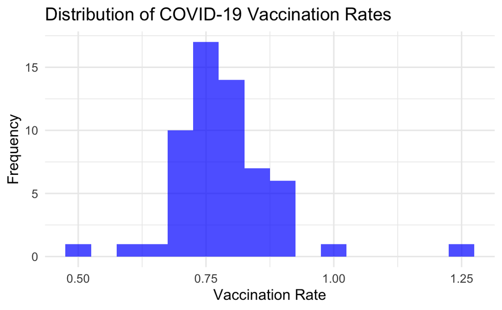

```r
ggplot(data, aes(x = covid_vax_rate)) +
  geom_histogram(binwidth = 0.05, fill = "blue", alpha = 0.7) +
  theme_minimal() +
  labs(title = "Distribution of COVID-19 Vaccination Rates", x = "Vaccination Rate", y = "Frequency")
```

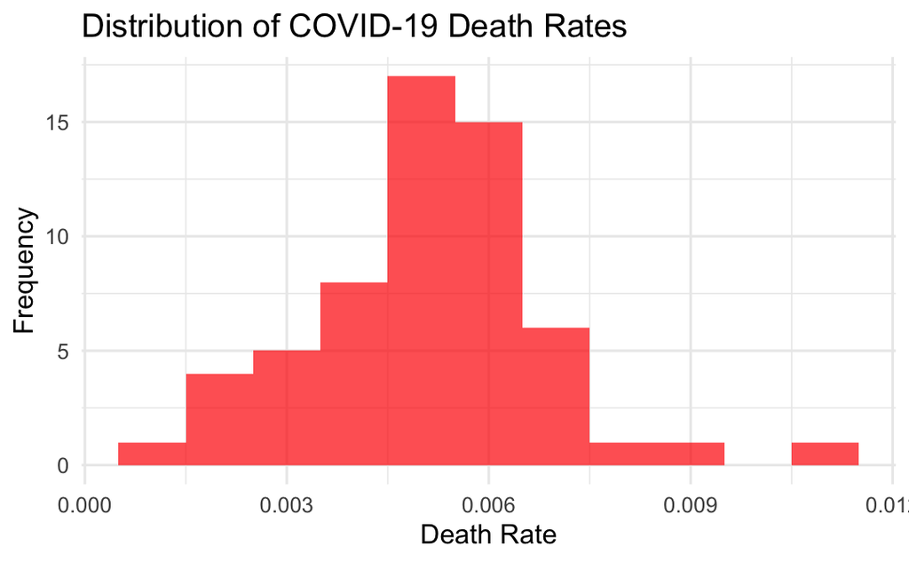

```r
ggplot(data, aes(x = covid_death_rate)) +
  geom_histogram(binwidth = 0.001, fill = "red", alpha = 0.7) +
  theme_minimal() +
  labs(title = "Distribution of COVID-19 Death Rates", x = "Death Rate", y = "Frequency")
```

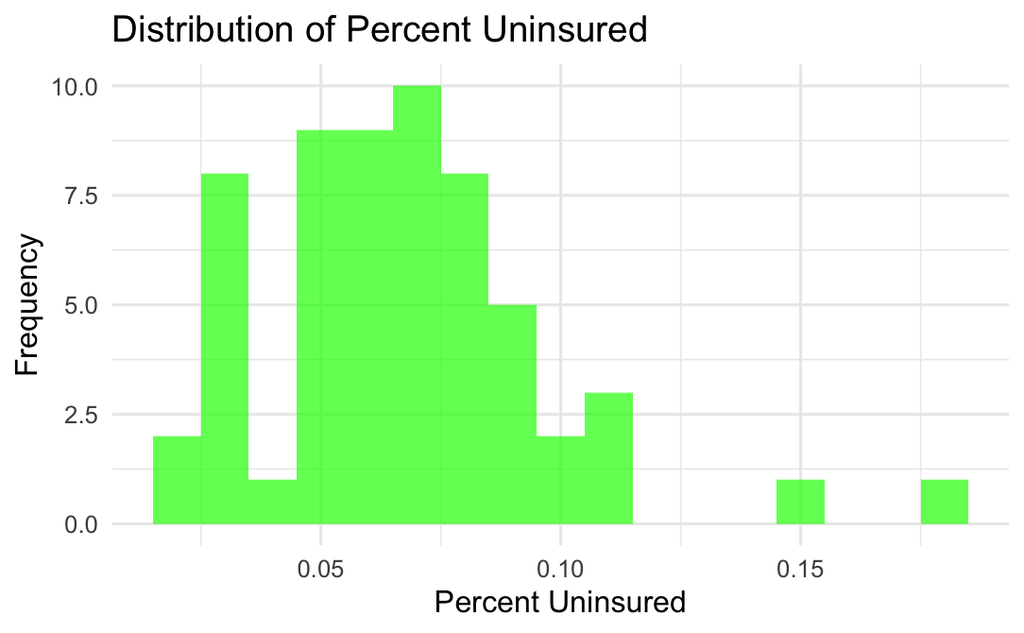

```r
ggplot(data, aes(x = percent_uninsured)) +
  geom_histogram(binwidth = 0.01, fill = "green", alpha = 0.7) +
  theme_minimal() +
  labs(title = "Distribution of Percent Uninsured", x = "Percent Uninsured", y = "Frequency")
```